# Course Review

Author

Kris Sankaran

## Final Takeaways

1. We’ve covered many practical visualization strategies in this course. However, I hope a few overarching themes have come across as well. In these notes, I will try articulating a few of these themes, and they are also the subject of the readings reviewed in the next few sections.
2. First, creating a visualization is in many ways like writing an essay. A great visualization cannot simply be summoned on demand. Instead, visualizations go through drafts, as the ideal graphical forms and questions of interest become clearer.
3. Visualization is not simply for consumption by external stakeholders. In data science, visualization can be used to support the process of exploration and discovery, before any takeaways have yet been found.
4. Visualization can be used throughout the data science process, from data quality assessment to model prediction analysis. In fact, I would be wary of any data science workflow that did not make use of visualization at multiple intermediate steps.
5. It pays dividends to think carefully about data format. A design can be easy to implement when the data are in tidy, but not wide, format, and vice versa.
6. Structured, nontabular data – think time series, spatial formats, networks, text, and images – are everywhere, and specific visualization idioms are available for each.
7. Similarly, high-dimensional data are commonplace, but a small catalog of techniques, like faceting, dynamic linking, PCA, and UMAP, are able to take us quite far.
8. Finally, data visualization can be enriching. Visual thinking has helped me navigate and appreciate complexity in many contexts. Through this course, I have shared techniques that I’ve found useful over the years, and I hope you find them handy as you go off and solve real-world data science problems.

## Design Process Case Study

[Reading](https://www.datasketch.es/project/655-frustrations-doing-data-visualization)

9. How does a visualization expert go about creating a data visualization? Perhaps the most useful lesson from this reading is that good visualizations don’t materialize out of thin air – there is always a creative process involved, steps where it’s unclear what the final result will be, even for a data visualization genius like Shirley Wu. We’re lucky that she has documented this process for us, so that we might be able to take away a few lessons for our own reflection.
10. Her visualization, [“655 Frustrations of Data Visualization”](https://shirleywu.studio/community/), is based on an online data visualization survey. It had 45 questions (“How many years have you been doing data visualization? What percent of your day is focused on data prep work? …). There are 981 responses, probably mostly submitted by the survey initiator’s internet following.

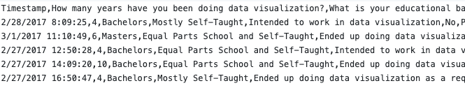

A few entries from the data visualization survey. The full data are publicly available [here](https://github.com/data-visualization-society/data_visualization_survey/blob/master/data/cleaned_survey_results_2017.csv).

### Question Formulation

11. At the start of the project – before writing code – there is the problem of choosing a guiding question. Her initial question was “Why might people leave the field?” This was a timely question, because, after a few years of high activity and visibility in industry, data visualization seemed to be cooling down. However, this question was not directly answerable with the data at hand, so instead, she focused on the proxy question, “Do you want to spend more time or less time visualizing data in the future?”
    - This is an important lesson: there is often a distinction between what we really want to know and what the data can tell us.
    - We will revisit this theme of asking sharper questions in the next reading. Data analysis should be driven by curiosity about the world, not simply the data that happen to be conveniently accessible.
12. To see what within the data are relevant to this guiding question, she then conducted an exploratory analysis[^1], studying the marginal distributions of all the available questions. For example, visualizing the “percentage of time” questions, it became clear that most people worked on a mix of multiple data-related tasks in their work – the particular mix might help understand whether people want to stay in the field.

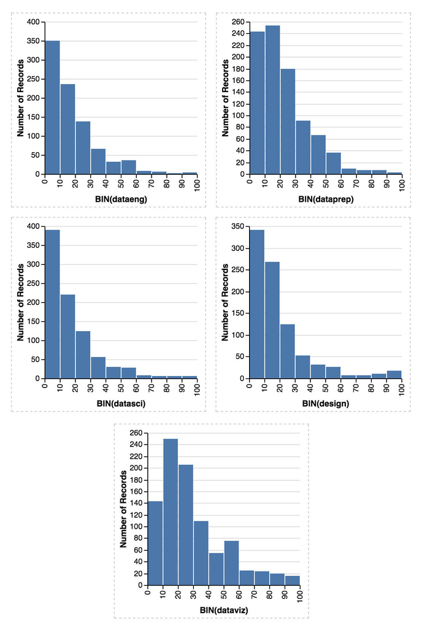

Example exploratory displays of the ‘percentage of time’ questions on the data science survey.

13. The exploratory analysis also revealed that there are [some questions](https://uploads-ssl.webflow.com/5fa9d88da1855554db37b1e1/5fc61cc3f46a9b23e56d8ad8_qualitative.jpeg) that would not be useful for answering the guiding question. For example, many of the qualitative responses were not useful[^2]. It’s easy to feel responsible for visualizing all the data that are available, but this is not necessary. It’s far more important to focus on the guiding question(s).

### Initial Design

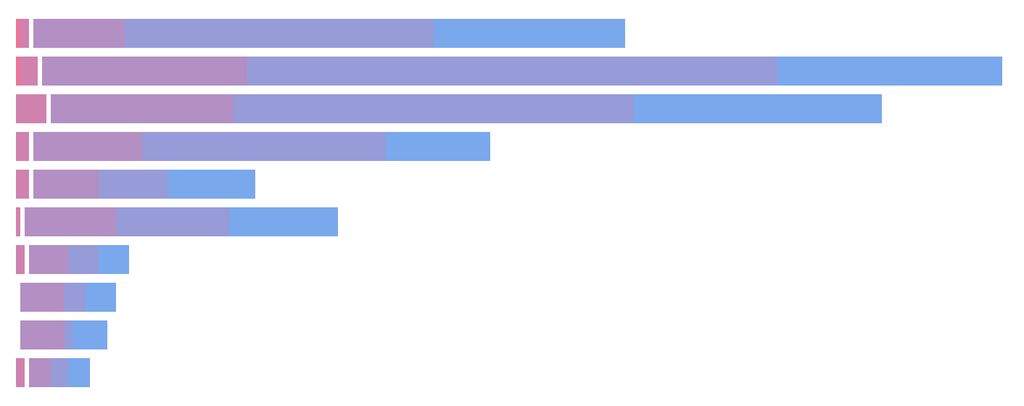

The initial design used a bar chart to see whether experience was related to interest in further work in data visualization.

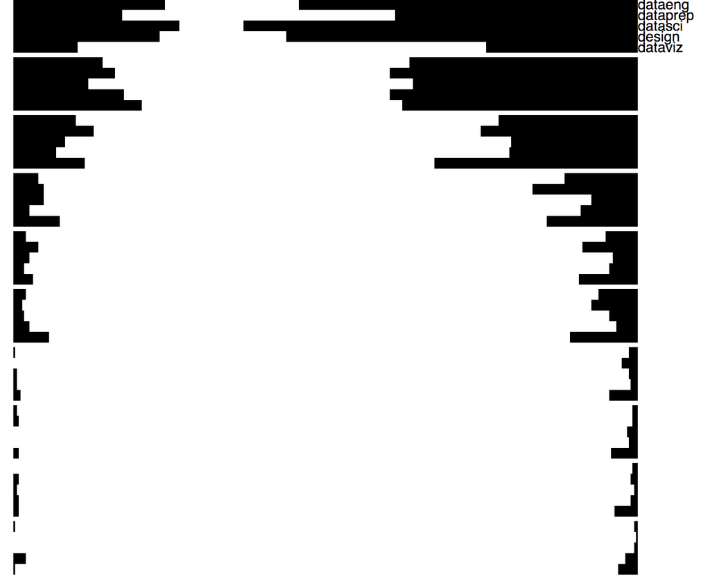

The faceted barchart did not add much information relevant to the guiding question.

### Redesigns

16. At this point, two significant changes to the design were made, one to the question, and one to the design. The question was reframed from “do you want to continue working in data visualization” to “do you experience any frustrations with data visualization.” This question is still related to the guiding question, but shows much more variation across respondents. For the design, the encoding changed from a stacked barchart to a beeswarm plot. Unlike the barchart, which aggregates responses into bins, the beeswarm makes it possible to see every single respondent.

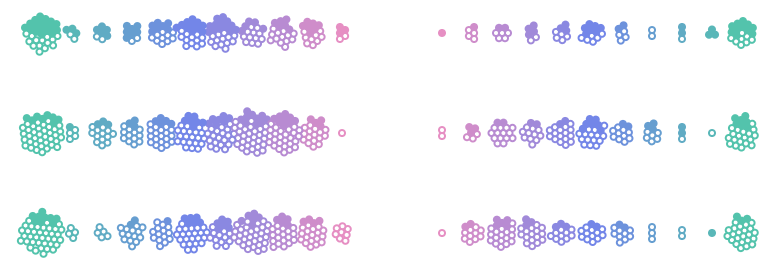

A redesigned plot. The left and right panels separate respondents with and without frustrations, vertical position encodes job role, and color gives number of years of experience.

17. A few more refinements were made. Instead of placing those with and without frustrations far apart on the page, they were rearranged to share the same $x$-axis[^4]. Also, instead of coloring circles by years of experience, color was used to represent the percentage of the day spent on data visualization. Again, these changes reflect sharpening of both design and questions.
18. In the final version of the static display, a boxplot was introduced to summarize the most salient characteristics of each beeswarm. Then, instead of just plotting the points in two parallel regions, they were made to “rise” and “fall” off the boxplots, depending on whether the respondents experienced frustrations. This kind of visual metaphor takes the visualization to another level; it becomes more than functional, it becomes evocative.

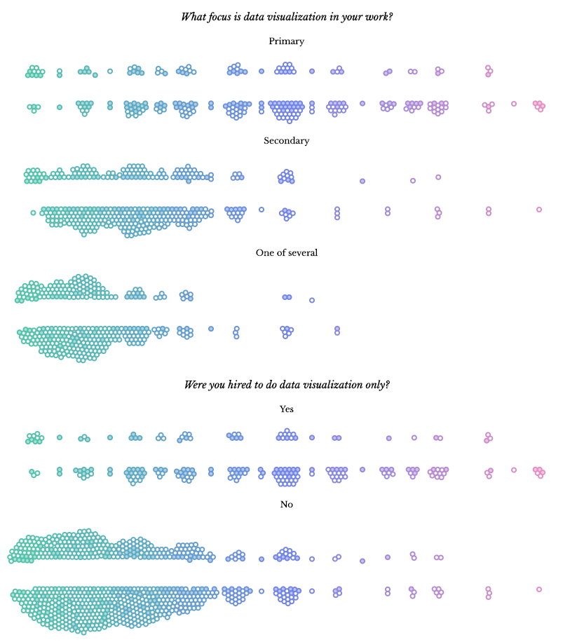

The final version of the static visualization.

### Interpretation

19. Only at this point is interactivity introduced into the visualization. The interactivity is simple – views transition into one another depending on selected questions – but provides an effective alternative to simply faceting all pairs of questions.

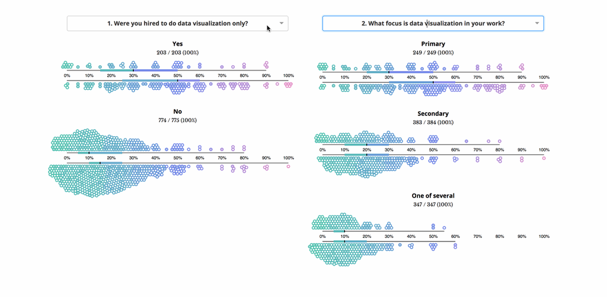

The visualization above with interactivity added in.

20. Finally, this interactive visualization is used for an extensive exploration. This is often when the effectiveness of a visualization can be evaluated. Ultimately, visualization should help inform our body of beliefs, guiding the actions we take (either in the short or long-term). If it’s hard to draw these sorts of inferences, then a visualization is not particularly functional.

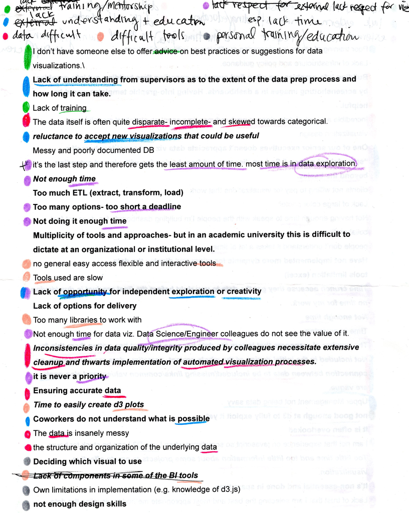

A screenshot of notes from the designer’s exploration of the resulting visualization.

21. To guide the reader, this investigative work was then incorporated into the visualization. These additional details allow the visualization to stand alone, it becomes a self-explanatory intellectual artifact.

### Conclusion

22. Wrapping up, the final visualization is clearly the culmination of substantial intellectual labor over the course of weeks (if not months). The result is both beautiful and informative. This is an ideal to strive for – the crafting of data visualizations that can guide discovery and change.
23. One final note. It’s often useful to study the development of projects that you find interesting. Sometimes, authors share their code on github, or earlier versions are available through technical reports or recorded talks. This additional context can shed light on the overall inspiration and intention of the project, and especially when starting out, imitation can be an effective strategy for learning.

## Asking Better Questions

[Reading](https://simplystatistics.org/posts/2019-04-17-tukey-design-thinking-and-better-questions/)

24. In these notes, we will review “Tukey, Design Thinking, and Better Questions,” a blog post by Roger Peng. In the post, he discusses the importance of formulating good questions in data analysis. While the process of refining questions is central to any successful, real-world analysis, it is rarely discussed in formal statistics textbooks, which usually restrict themselves to developments in theory, methodology, or computation.
25. The post itself is based on a line of thinking from the statistician John Tukey’s 1962 paper, “The Future of Data Analysis.” Perhaps the most famous quote from this paper is,

    > Far better an approximate answer to the right question, which is often vague, than an exact answer to the wrong question, which can always be made precise.

    and throughout the article, Tukey argues that data analysts should not (1) be called upon to provide stamps of authority and (2) be distracted by the allure of proving optimal algorithms in settings that are likely not that realistic.
26. This of course begs the question – what should data analysts be doing? Tukey never directly discusses this, but Peng’s thesis is that the purpose of data analysis is to spark the formulation of better questions. This idea is captured in the diagram below. The idea is that algorithms (visual, predictive, and inferential) can help us strengthen evidence that certain patterns exist. However, if those patterns answer irrelevant questions, then there is little point in the analysis. With so many algorithms available, it’s easy to spend substantial effort gathering evidence to answer low quality questions. Instead, a good data scientist should focus on improving the quality of the questions asked, even if that means that the answers will be less definitive.

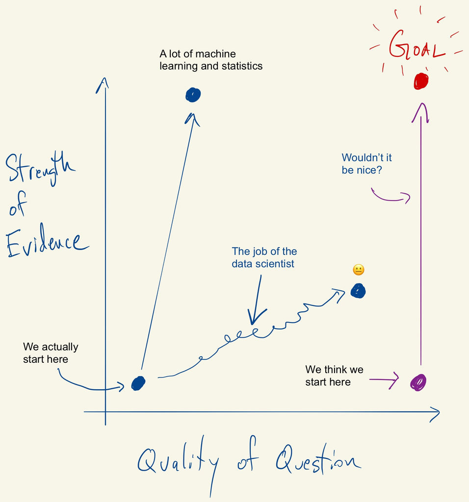

Peng’s summary of misplaced priorities in the data science process.

27. What does it mean to ask better questions? Peng argues that better questions are “sharper,” providing more discriminating information and guiding research to more promising directions. In my view, a sharper question is one that helps inform decisions that have to be made (all data aside), either by adding to our body of beliefs or bringing new uncertainties into focus.
28. The implication is that data analysis is not about finding “the answer.” Instead, it should be about clarifying what can and cannot be answered based on the data. But more, it can help clarify what questions we really want answered – in Peng’s words, “we can learn more about ourselves by looking at the data.”
29. The final example in the reading is that the residuals in an analysis are themselves data worth examining. They inform whether a model (and the associated way of conceptualizing the problem) is really appropriate, or whether a reformulation would be beneficial.
30. At the end, the main idea is that data analysis equips us to ask better questions.

## A History of Data Visualization up to 1900

[Reading](https://datavis.ca/papers/hbook.pdf)

31. There could probably be an entire class taught on the history of data visualization. The reason it is worth covering in an otherwise practically-oriented class is that,
    - Historical study can illuminate the core intellectual foundation on which the entire discipline of data visualization is built.
    - The limits, biases, and trends of our current era become clear when considering it within its full historical context.
    - It’s often possible to draw inspiration from past masters.
    - It can be humbling to realize that now-commonplace ideas had to be discovered. If it took until 1833 until the first scatterplot was published, then what ideas have we yet to find?
32. The reading divides up the history of data visualization into 8 epochs. In these notes, we will consider the 5 epochs before 1900.

### Before 1600: Early Maps and Diagrams

33. It might come as a surprise, but visualization has been around since the invention of writing. The Egyptians made maps, and there are examples multiple time series plots from the 10th century.

[figure not shown]

Possibly the earliest multiple time series visualization, showing the movement of various planets, from *In Somnium Scripionus*.

34. However, most visualizations were focused on physical geographical or astronomical quantities, and even these quantities were only imprecisely measured. Without more formal data gathering instruments, there could not be much data visualization.

### 1600 - 1700: Measurement and Theory

35. The situation begins to change around 1600, at the dawn of the scientific revolution. All of a sudden, precise measurement of physical space become possible. Also, important new mathematical ideas were introduced, like probability, calculus, and reasoning about functions. This created the right environment for the design of some of the first truly sophisticated data visualizations, like
- Christopher Scheiner’s 1630 visualization of sunspots over time (a first instance of faceting),

[figure not shown]

Scheiner’s visualization of sunspots, which played a role in his dialogues with Galileo.

- Edmond Halley’s plot of barometric pressure against altitude (a first instance of one feature being plotted against another), and

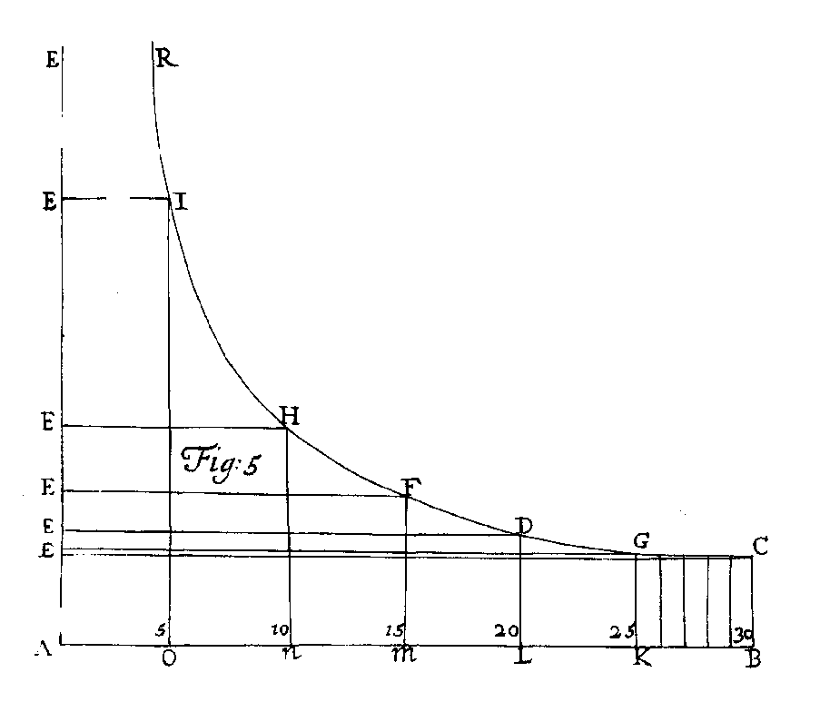

One of the first bivariate plots, relating barometric pressure to altitude. Note that absence of the true observed data.

- Edmond Halley’s plot of wind speed over the ocean (a first visualization of a vector field).

[figure not shown]

A plot of trade winds, appearing in *An Historical Account of the Trade Winds, and Monsoons, Observable in the Seas between and near the Tropicks, with an Attempt to Assign the Phisical Cause of the Said Wind*.

36. During this period, the scientific value of visual thinking was more or less established. However, there were still only relatively few graphical forms available, and the focus continued to remain on visualizing physical quantities, rather than more general social, economic, biological, or ecological data.

### 1700 - 1800

37. During this period, many new graphical forms were invented, including timelines, cartograms, functional interpolations, line graphs, bar charts, and pie charts. Further, forms from earlier, like maps and function plots, became more firmly established.
38. This was also when three-color printing was invented. Before this point, color could not be used as an encoding channel.
39. In this century, governments also began large-scale data collection of social and economic statistics[^5]. One of the most prolific inventors of data visualizations, William Playfair[^6], was used visualization to study a variety of economic problems. In addition to inventing line, bar, and pie charts, he experimented with original ways of composing multiple graphs to suggest the relationships between variables.

[figure not shown]

One of William Playfair’s data visualizations, juxtaposing the price of wheat with growth in wages.

### 1800 - 1850

40. This was a period of maturation for the field of data visualization. By this point, visualization had become standard in scientific publications. Advances in printing technology also made it also became easier to mass produce visualizations.
41. It was also around this time that the scope of problems studied through visualization expanded far beyond display of purely physical (geographical and astronomical) applications. Two areas in particular flourished, applications to social science and to engineering.
- Visualization in the social sciences began to emerged in response to government sponsored collection of social statistics – data about crime, births, and deaths, among other topics. This wasn’t a purely intellectual exercise: understanding demographic trends was important for countries that were often at war with another.

[figure not shown]

A visualization of property crime statistics, by Andre-Michel Guerry (1829).

- In engineering, the idea that visualization could serve as a computational aid become more and more common. For example, rather the chart below, by Charles Joseph Minard, displays the cost of transporting goods across different stretches of a canal. Vertical breaks correspond to cities along the canal, and the area of the square between cities encodes the cost of transportation between those cities. While the information could be stored in a table, it becomes easier to perform mental computations (and make guesstimates) using the display.

[figure not shown]

Minard’s 1844 visualization of the transport costs across the Canal du Centre in France.

### 1850 - 1900: The Golden Age

[figure not shown]

Florence Nightingale’s visualization of hospital mortality statistics from the Crimean War, used to support a campaign for sanitary reforms.

44. Some of the graphical innovations include,
- 3D function plots. The plot below, by Luigi Perozzo, shows population size broken down into age groups and traced over time.

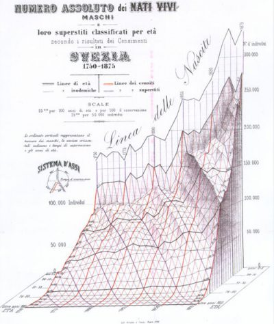

Luigi Perrozo’s 1879 3D visualizations of population over time.

- Flow diagrams. Charles-Joseph Minard, who we met before with the canal visualization, was a master of these displays. One in particular is widely considered a masterpiece, it shows the size of Napoleon’s army during it’s Russian Campaign.

[figure not shown]

Minard’s flow display of the size of Napoleon’s army during the Russia Campaign.

- Multivariate visualization. Francis Galton made some of the first efforts to visualize more than 3 variables at a time. His *Meteorographica*, published in 1863, contained over 600 visualizations of weather data that had been collected for decades, but never visualized. One plot, shown below, led to the discovery of anticyclones.

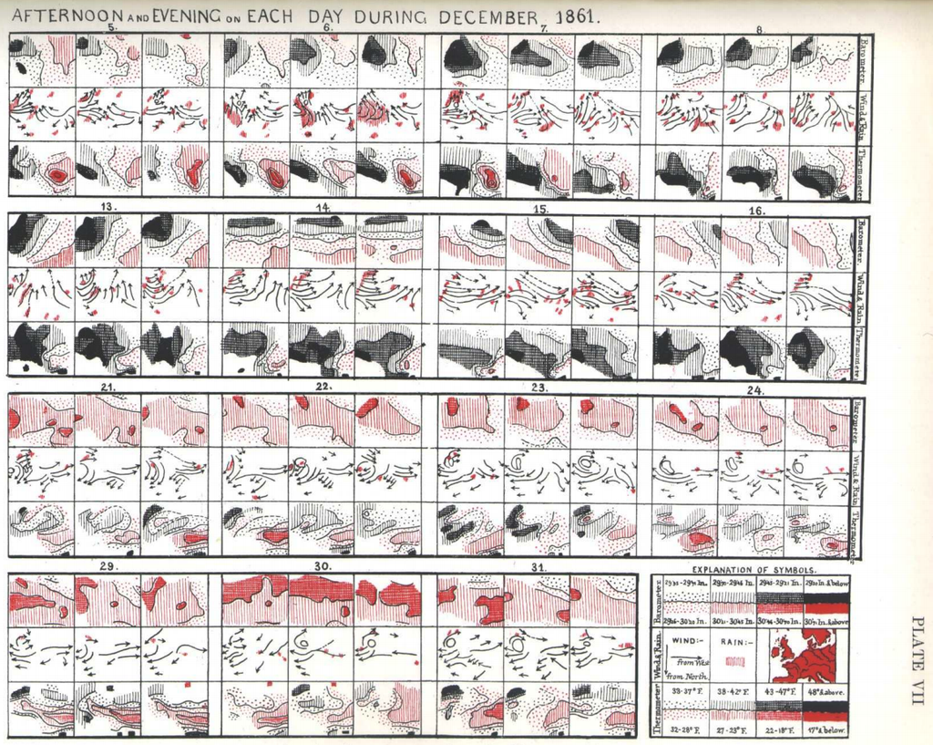

45. This was also an age of state-sponsored atlases. More than sponsoring the collection of data, governments assembled teams to visualize the results for official publication. From 1879 to 1897, the French Ministry of Public Works published the *Albums de Statistique Graphique*, which under the guidance of Émile Cheysson, developed some of the most imaginative and ambitious visualizations of the era.

[figure not shown]

A visualization of the flow of passengers and goods through railways from Paris. Each square shows the breakdown to cities further away, and color encodes the railines.

## Footnotes

[^1]: Using vega-lite!
[^2]: Are there really 100x more pie charts than scatterplots in industry??
[^3]: Perhaps an instance of selection bias.
[^4]: The less our eyes have to travel across the page to make a comparison, the more efficient the visualization.
[^5]: The word “statistics” comes from the same root as “state”, since it originally focused on data collected for governance.
[^6]: He has been described as an “engineer, political economist and scoundrel.”